# Downsampling simulations

# Introduction

In this Report we want to build a very simple simulation of the effect of the number of UMIs/cell on the relative expression estimation and the distances between cells.

First we will use the cell with the highest number of UMIs from our cta-seq experiment as a ground-truth.

```r
deep_counts <- readRDS(file = '../data/umi_tools_corrected_deep_counts.RDS')

deepest_cell <- deep_counts %>%
  select(gene, `TCTCTGGGTGTGCTTA-1`) %>%
  mutate(ground_truth = `TCTCTGGGTGTGCTTA-1`/sum(`TCTCTGGGTGTGCTTA-1`) )

deep_count_mtx <- deep_counts %>% select(-gene) %>% as.matrix()
rownames(deep_count_mtx) <- deep_counts$gene

deep_count_mtx_norm <- t(t(deep_count_mtx)/colSums(deep_count_mtx))

deep_dists <- dist(t(deep_count_mtx_norm), diag = T) %>% as.matrix
deep_dists <- deep_dists %>% replace(lower.tri(deep_dists),0)

deep_dist_list <- deep_dists %>% as.numeric()
deep_dist_list_filtered <- deep_dist_list[deep_dist_list != 0]
```

The mean Euclidean distance between our deep sequenced cells is 0.0173359

# Random Sampling

Now we sample different numbers of UMIs from this ground-truth with replacement, and calculate the errors made when estimating the relative gene expression vector using the Maximum-Likelihood and the Good-Turing estimator.

```r
sizes <- 10**(seq(2, 5, length.out = 20))

deepest_cell_vct <- as.numeric(deepest_cell$`TCTCTGGGTGTGCTTA-1`)
names(deepest_cell_vct) <- deepest_cell$gene

re_error_tbl <- tibble()
for (i in sizes){
  sampled_matrix <- downsample_vct(deepest_cell_vct, n = 1000, size = i)

  ML_matrix <- t(t(sampled_matrix)/colSums(sampled_matrix))
  GT_matrix <- GTestimate(sampled_matrix, size.factor = 1, log1p.transform = F)

  ML_abs_errors <- colSums(apply(ML_matrix, 2, function(x) abs(x - deepest_cell$ground_truth)))
  GT_abs_errors <- colSums(apply(GT_matrix, 2, function(x) abs(x - deepest_cell$ground_truth)))

  ML_sq_errors <- colSums(apply(ML_matrix, 2, function(x) (x - deepest_cell$ground_truth)**2))
  GT_sq_errors <- colSums(apply(GT_matrix, 2, function(x) (x - deepest_cell$ground_truth)**2))

  re_error_tbl <- re_error_tbl %>%
    rbind(tibble(Error = ML_abs_errors, error_type = 'absolute', size = i, Method = 'ML')) %>%
    rbind(tibble(Error = ML_sq_errors, error_type = 'squared', size = i, Method = 'ML')) %>%
    rbind(tibble(Error = GT_abs_errors, error_type = 'absolute', size = i, Method = 'GT')) %>%
    rbind(tibble(Error = GT_sq_errors, error_type = 'squared', size = i, Method = 'GT'))
}
```

# Estimation Error

Now we can summarize the results for the estimation error and make some plots:

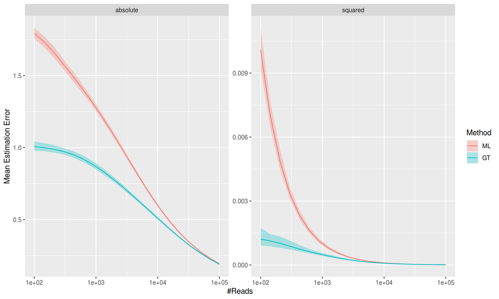

```r
re_error_tbl_mean <- re_error_tbl %>%
  group_by(error_type, Method, size) %>%
  summarize(mean_error = mean(Error), sd = sd(Error), range_lower = quantile(Error, probs = 0.05), range_higher = quantile(Error, probs = 0.95)) %>%
  mutate(Method = factor(Method, levels = c('ML', 'GT')))


combined_error_plot <- ggplot(re_error_tbl_mean) +
  geom_line(aes(x = size, y = mean_error, col = Method)) +
  geom_ribbon(aes(x = size, ymin = range_lower, ymax = range_higher, fill = Method), alpha = 0.3) +
  facet_wrap(~error_type, scales = 'free') +
  scale_x_continuous(trans = 'log10') +
  ylab('Mean Estimation Error') +
  xlab('#Reads')

max_abs <- re_error_tbl_mean %>% filter(error_type == 'absolute') %>% pluck('range_higher') %>% max

abs_error_plot <- ggplot(re_error_tbl_mean %>% filter(error_type == 'absolute')) +
  geom_line(aes(x = size, y = mean_error, col = Method)) +
  geom_ribbon(aes(x = size, ymin = range_lower, ymax = range_higher, fill = Method), alpha = 0.3) +
  scale_x_continuous(trans = 'log10') +
  scale_y_continuous(limits = c(0, max_abs)) +
  ylab('Mean Error') +
  xlab('#Reads') +
  ggtitle('Absolute Error')

max_sq <- re_error_tbl_mean %>% filter(error_type == 'squared') %>% pluck('range_higher') %>% max

sq_error_plot <- ggplot(re_error_tbl_mean %>% filter(error_type == 'squared')) +
  geom_line(aes(x = size, y = mean_error, col = Method)) +
  geom_ribbon(aes(x = size, ymin = range_lower, ymax = range_higher, fill = Method), alpha = 0.3) +
  scale_x_continuous(trans = 'log10') +
  scale_y_continuous(limits = c(0, max_sq)) +
  ylab('Mean Error') +
  xlab('#Reads') +
  ggtitle('Squared Error')

combined_error_plot
```

```r
ggsave(str_glue('{folder}abs_error_plot.pdf'), abs_error_plot, width = 6.6, height = 4)
ggsave(str_glue('{folder}sq_error_plot.pdf'), sq_error_plot, width = 6.6, height = 4)
saveRDS(file = str_glue('{folder}abs_error_plot.Rds'), abs_error_plot)
saveRDS(file = str_glue('{folder}sq_error_plot.Rds'), sq_error_plot)
```

# Distances between cells

Now let’s look at the distances between cells, first the average distance between two random samplings of the same cell. This gives us some inside on the baseline sampling noise.

```r
re_dists_tbl <- tibble()
for (i in sizes){
  sampled_matrix_1 <- downsample_vct(deepest_cell_vct, n = 1000, size = i)
  sampled_matrix_2 <- downsample_vct(deepest_cell_vct, n = 1000, size = i)

  ML_matrix_1 <- t(t(sampled_matrix_1)/colSums(sampled_matrix_1))
  GT_matrix_1 <- GTestimate(sampled_matrix_1, size.factor = 1, log1p.transform = F)

  ML_matrix_2 <- t(t(sampled_matrix_2)/colSums(sampled_matrix_2))
  GT_matrix_2 <- GTestimate(sampled_matrix_2, size.factor = 1, log1p.transform = F)

  for(j in 1:1000){
    ML_abs_dist <- sum(abs(ML_matrix_1[,j] - ML_matrix_2[,j]))
    GT_abs_dist <- sum(abs(GT_matrix_1[,j] - GT_matrix_2[,j]))

    ML_sq_dist <- sqrt(sum((ML_matrix_1[,j] - ML_matrix_2[,j])**2))
    GT_sq_dist <- sqrt(sum((GT_matrix_1[,j] - GT_matrix_2[,j])**2))

    re_dists_tbl <- re_dists_tbl %>%
      rbind(tibble(Distance = ML_abs_dist, Metric = 'Manhattan', Method = 'ML', size = i, comparisson = 'same')) %>%
      rbind(tibble(Distance = GT_abs_dist, Metric = 'Manhattan', Method = 'GT', size = i, comparisson = 'same')) %>%
      rbind(tibble(Distance = ML_sq_dist, Metric = 'Euclidean', Method = 'ML', size = i, comparisson = 'same')) %>%
      rbind(tibble(Distance = GT_sq_dist, Metric = 'Euclidean', Method = 'GT', size = i, comparisson = 'same'))
  }
}
```

And we can repeat this for two different cells from our cta-seq data-set, here we ll use the two cells with the most UMIs, which are from two different cell-types.

```r
second_deepest_cell <- deep_counts %>%
  select(gene, `GGCTTTCGTGTGTCGC-1`) %>%
  mutate(ground_truth = `GGCTTTCGTGTGTCGC-1`/sum(`GGCTTTCGTGTGTCGC-1`) )

second_deepest_cell_vct <- as.numeric(second_deepest_cell$`GGCTTTCGTGTGTCGC-1`)
names(second_deepest_cell_vct) <- second_deepest_cell$gene

for (i in sizes){
  sampled_matrix_1 <- downsample_vct(deepest_cell_vct, n = 1000, size = i)
  sampled_matrix_2 <- downsample_vct(second_deepest_cell_vct, n = 1000, size = i)

  ML_matrix_1 <- t(t(sampled_matrix_1)/colSums(sampled_matrix_1))
  GT_matrix_1 <- GTestimate(sampled_matrix_1, size.factor = 1, log1p.transform = F)

  ML_matrix_2 <- t(t(sampled_matrix_2)/colSums(sampled_matrix_2))
  GT_matrix_2 <- GTestimate(sampled_matrix_2, size.factor = 1, log1p.transform = F)

  for(j in 1:1000){
    ML_abs_dist <- sum(abs(ML_matrix_1[,j] - ML_matrix_2[,j]))
    GT_abs_dist <- sum(abs(GT_matrix_1[,j] - GT_matrix_2[,j]))

    ML_sq_dist <- sqrt(sum((ML_matrix_1[,j] - ML_matrix_2[,j])**2))
    GT_sq_dist <- sqrt(sum((GT_matrix_1[,j] - GT_matrix_2[,j])**2))

    re_dists_tbl <- re_dists_tbl %>%
      rbind(tibble(Distance = ML_abs_dist, Metric = 'Manhattan', Method = 'ML', size = i, comparisson = 'different')) %>%
      rbind(tibble(Distance = GT_abs_dist, Metric = 'Manhattan', Method = 'GT', size = i, comparisson = 'different')) %>%
      rbind(tibble(Distance = ML_sq_dist, Metric = 'Euclidean', Method = 'ML', size = i, comparisson = 'different')) %>%
      rbind(tibble(Distance = GT_sq_dist, Metric = 'Euclidean', Method = 'GT', size = i, comparisson = 'different'))
  }
}
```

# Visualization of Distances

we can plot the results distances at various UMIs/cell for the same cell twice:

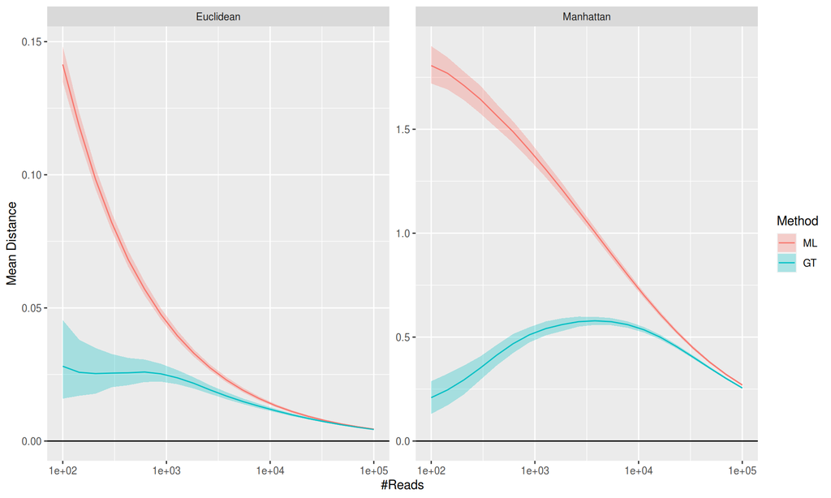

```r
re_dists_tbl_same_mean <- re_dists_tbl %>%
  filter(comparisson == 'same') %>%
  group_by(Metric, Method, size) %>%
  summarize(mean_distance = mean(Distance), sd = sd(Distance), range_lower = quantile(Distance, probs = 0.05), range_higher = quantile(Distance, probs = 0.95)) %>%
  mutate(Method = factor(Method, levels = c('ML', 'GT')))

re_dists_tbl_different_mean <- re_dists_tbl %>%
  filter(comparisson == 'different') %>%
  group_by(Metric, Method, size) %>%
  summarize(mean_distance = mean(Distance), sd = sd(Distance), range_lower = quantile(Distance, probs = 0.05), range_higher = quantile(Distance, probs = 0.95)) %>%
  mutate(Method = factor(Method, levels = c('ML', 'GT')))

max_euclidean_diff <- re_dists_tbl_different_mean %>% filter(Metric == 'Euclidean') %>% pluck('range_higher') %>% max
max_euclidean_same <- re_dists_tbl_same_mean %>% filter(Metric == 'Euclidean') %>% pluck('range_higher') %>% max
max_euclidean <- max(max_euclidean_diff, max_euclidean_same)

max_manhattan_diff <- re_dists_tbl_different_mean %>% filter(Metric == 'Manhattan') %>% pluck('range_higher') %>% max
max_manhattan_same <- re_dists_tbl_same_mean %>% filter(Metric == 'Manhattan') %>% pluck('range_higher') %>% max
max_manhattan <- max(max_manhattan_diff, max_manhattan_same)

combined_same_dist_plot <- ggplot(re_dists_tbl_same_mean) +
  geom_line(aes(x = size, y = mean_distance, col = Method)) +
  geom_ribbon(aes(x = size, ymin = range_lower, ymax = range_higher, fill = Method), alpha = 0.3) +
  facet_wrap(~Metric, scales = 'free') +
  geom_hline(yintercept = 0) +
  scale_x_continuous(trans = 'log10') +
  xlab('#Reads') +
  ylab('Mean Distance')

manhattan_same_dist_plot <- ggplot(re_dists_tbl_same_mean %>% filter(Metric == 'Manhattan')) +
  geom_line(aes(x = size, y = mean_distance, col = Method)) +
  geom_ribbon(aes(x = size, ymin = range_lower, ymax = range_higher, fill = Method), alpha = 0.3) +
  geom_hline(yintercept = 0) +
  scale_x_continuous(trans = 'log10') +
  xlab('#Reads') +
  ylab('Mean Distance') +
  ggtitle('Manhattan Distance') +
  scale_y_continuous(limits = c(0, max_manhattan))

euclidean_same_dist_plot <- ggplot(re_dists_tbl_same_mean %>% filter(Metric == 'Euclidean')) +
  geom_line(aes(x = size, y = mean_distance, col = Method)) +
  geom_ribbon(aes(x = size, ymin = range_lower, ymax = range_higher, fill = Method), alpha = 0.3) +
  geom_hline(data = tibble(distance = 0), aes(yintercept = distance, linetype = 'ground truth')) +
  scale_x_continuous(trans = 'log10') +
  xlab('#Reads') +
  ylab('Mean Distance') +
  ggtitle('Euclidean Distance') +
  scale_linetype_manual(name = element_blank(), values = 2) +
  scale_y_continuous(limits = c(0, max_euclidean))

combined_same_dist_plot
```

```r
ggsave(str_glue('{folder}manhattan_same_dist_plot.pdf'), manhattan_same_dist_plot, width = 6.6, height = 4)
ggsave(str_glue('{folder}euclidean_same_dist_plot.pdf'), euclidean_same_dist_plot, width = 6.6, height = 4)
saveRDS(file = str_glue('{folder}manhattan_same_dist_plot.Rds'), manhattan_same_dist_plot)
saveRDS(file = str_glue('{folder}euclidean_same_dist_plot.Rds'), euclidean_same_dist_plot)
```

And again for two different cells:

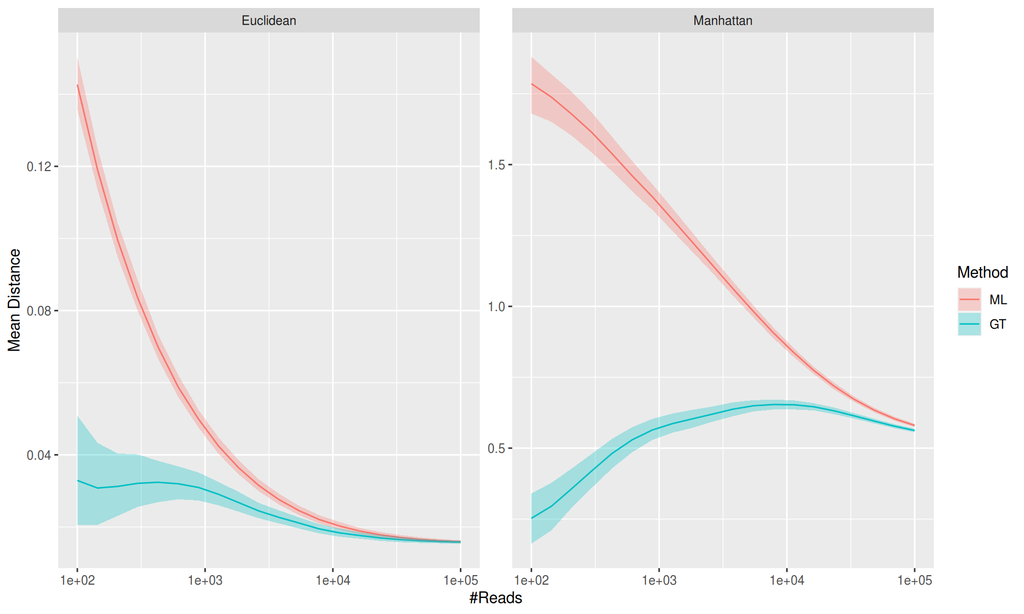

```r
real_manhattan_dist <- sum(abs(deepest_cell$ground_truth - second_deepest_cell$ground_truth))
real_euclidean_dist <- sqrt(sum((deepest_cell$ground_truth - second_deepest_cell$ground_truth)**2))


combined_different_dist_plot <- ggplot(re_dists_tbl_different_mean) +
  geom_line(aes(x = size, y = mean_distance, col = Method)) +
  geom_ribbon(aes(x = size, ymin = range_lower, ymax = range_higher, fill = Method), alpha = 0.3) +
  facet_wrap(~Metric, scales = 'free') +
  scale_x_continuous(trans = 'log10') +
  xlab('#Reads') +
  ylab('Mean Distance')

manhattan_different_dist_plot <- ggplot(re_dists_tbl_different_mean %>% filter(Metric == 'Manhattan')) +
  geom_line(aes(x = size, y = mean_distance, col = Method)) +
  geom_ribbon(aes(x = size, ymin = range_lower, ymax = range_higher, fill = Method), alpha = 0.3) +
  geom_hline(yintercept = real_manhattan_dist) +
  scale_y_continuous(limits = c(0, max_manhattan)) +
  scale_x_continuous(trans = 'log10') +
  xlab('#Reads') +
  ylab('Mean Distance') +
  ggtitle('Manhattan Distance')

euclidean_different_dist_plot <- ggplot(re_dists_tbl_different_mean %>% filter(Metric == 'Euclidean')) +
  geom_line(aes(x = size, y = mean_distance, col = Method)) +
  geom_ribbon(aes(x = size, ymin = range_lower, ymax = range_higher, fill = Method), alpha = 0.3) +
  geom_hline(data = tibble(distance = real_euclidean_dist), aes(yintercept = distance, linetype = 'ground truth')) +
  scale_y_continuous(limits = c(0, max_euclidean)) +
  scale_x_continuous(trans = 'log10') +
  xlab('#Reads') +
  ylab('Mean Distance') +
  ggtitle('Euclidean Distance') +
  scale_linetype_manual(name = element_blank(), values = 2)

combined_different_dist_plot
```

```r
ggsave(str_glue('{folder}manhattan_different_dist_plot.pdf'), manhattan_different_dist_plot, width = 6.6, height = 4)
ggsave(str_glue('{folder}euclidean_different_dist_plot.pdf'), euclidean_different_dist_plot, width = 6.6, height = 4)
saveRDS(file = str_glue('{folder}manhattan_different_dist_plot.Rds'), manhattan_different_dist_plot)
saveRDS(file = str_glue('{folder}euclidean_different_dist_plot.Rds'), euclidean_different_dist_plot)
```

# Difference between same and different cells

How large is the distance difference between same cells and different cells (signal to noise ratio)?

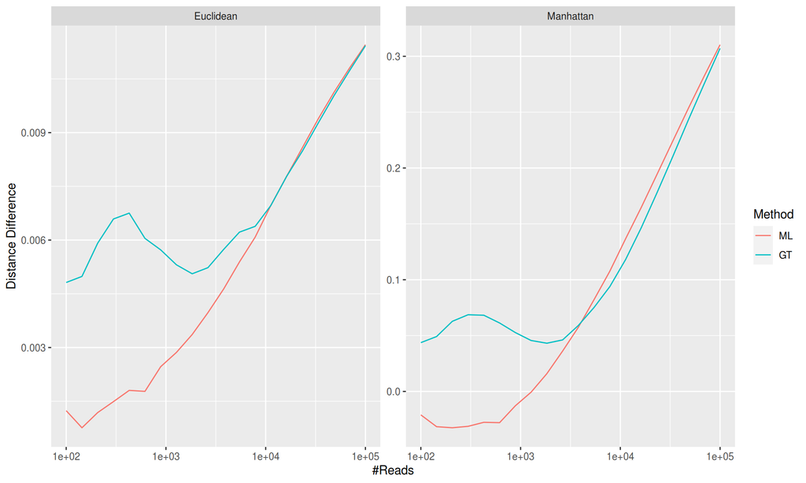

```r
re_dists_tbl_diff <- re_dists_tbl %>%
  group_by(comparisson, Metric, Method, size) %>%
  summarize(mean = mean(Distance), sd = sd(Distance), n = n()) %>%
  pivot_wider(names_from = comparisson, values_from = c(mean, sd, n)) %>%
  mutate(dist_difference = mean_different - mean_same) %>%
  group_by(Metric, Method, size) %>%
  mutate(Method = factor(Method, levels = c('ML', 'GT')))

combined_dist_diff_plot <- ggplot(re_dists_tbl_diff) +
  geom_line(aes(x = size, y = dist_difference, col = Method)) +
  facet_wrap(~Metric, scales = 'free') +
  scale_x_continuous(trans = 'log10') +
  xlab('#Reads') +
  ylab('Distance Difference')

euclidean_dist_diff_plot <- ggplot(re_dists_tbl_diff %>% filter(Metric == 'Euclidean')) +
  geom_line(aes(x = size, y = dist_difference, col = Method)) +
  scale_x_continuous(trans = 'log10') +
  xlab('#Reads') +
  ylab('Distance Difference') +
  ggtitle('Euclidean Distance')

manhattan_dist_diff_plot <- ggplot(re_dists_tbl_diff %>% filter(Metric == 'Manhattan')) +
  geom_line(aes(x = size, y = dist_difference, col = Method)) +
  scale_x_continuous(trans = 'log10') +
  xlab('#Reads') +
  ylab('Distance Difference') +
  ggtitle('Manhattan Distance')

combined_dist_diff_plot
```

```r
ggsave(str_glue('{folder}manhattan_dist_diff_plot.pdf'), manhattan_dist_diff_plot, width = 6.6, height = 4)
ggsave(str_glue('{folder}euclidean_dist_diff_plot.pdf'), euclidean_dist_diff_plot, width = 6.6, height = 4)
saveRDS(file = str_glue('{folder}manhattan_dist_diff_plot.Rds'), manhattan_dist_diff_plot)
saveRDS(file = str_glue('{folder}euclidean_dist_diff_plot.Rds'), euclidean_dist_diff_plot)
```